# EDA Report

Tiffany Jeung

May 6, 2018

# Overview

The goal of this exploratory data analysis is to gain a basic overview of the data. The data in question is Donald Trump’s tweets (@realDonaldTrump) from 5/4/2009 - 5/5/2018. The dataset can be found, thanks of Michael Kearney and his package rtweet here: https://bit.ly/2Ha0UEF. I will also explore tweets from the Twitter accoutn foxandfriends. Tidied versions of these datasets may be found in the processed subdirectory of the data folder.

#### Load Packages + Data

```r
# Load packages
library(tidyverse)
library(lubridate)
library(rtweet)

# Load data
train_trump <- readRDS(file = "data/processed/train_trump.rds")
train_fox <- readRDS(file = "data/processed/train_fox.rds")
```

### @realDonaldTrump

Important dates:  
1. Trump announced candidacy for president June 16, 2015.  
2. Trump became president on Jan 20, 2017.

This dataset runs from May 4, 2009, until May 5, 2018. The training set (80 percent) has 28970 observations and the test set (20 percent) has the remainder. There are some missing values in interaction values (retweets and favorites), but at ~1000 tweets of 28970, I have discarded them for this EDA, as they should not make an enormous difference in the findings. The missing values are scattered across years.

```r
# Missing values
rt <- train_trump %>%
  arrange(desc(retweet_count)) %>%
  select(retweet_count, created_at, text, favorite_count)

# 1070 missing retweet/favorite values
sum(is.na(rt$retweet_count))
```

```
## [1] 1046
```

```r
sum(is.na(rt$favorite_count))
```

```
## [1] 1046
```

```r
# Remove missing retweets counts
rt <- rt %>%
  filter(!is.na(retweet_count) & !is.na(favorite_count))
```

As expected, becoming president bolstered Donald Trump’s twitter fame.

```r
# Average retweets pre presidency
round(mean(rt_pre_pres$retweet_count), 0)
```

```
## [1] 1476
```

```r
# Average retweets from presidency on
round(mean(rt_pres$retweet_count), 0)
```

```
## [1] 19096
```

```r
# Average favorites pre presidency
round(mean(rt_pre_pres$favorite_count), 0)
```

```
## [1] 3691
```

```r
# Average favorites from presidency on
round(mean(rt_pres$favorite_count), 0)
```

```
## [1] 77439
```

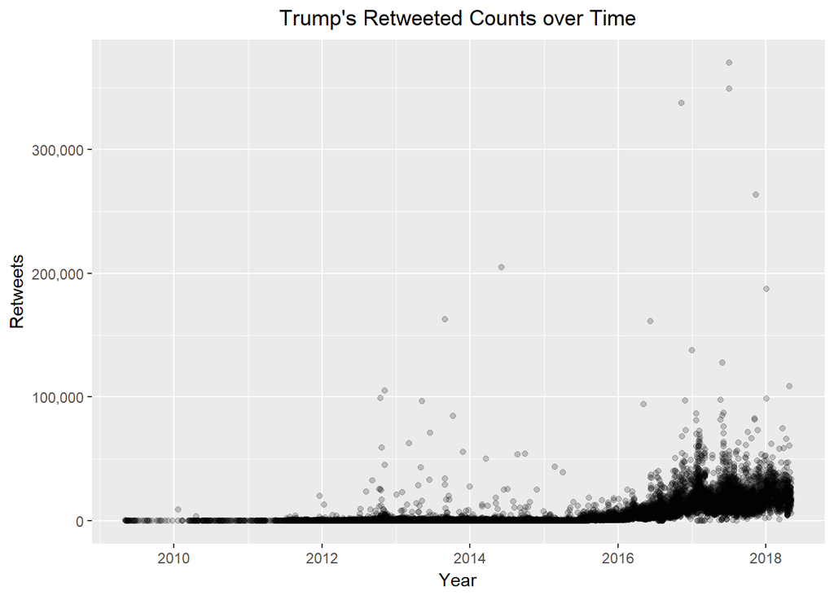

His climb appears catalyzed by his 2016 presidential campaign and peaked in both favorites and retweets in January 2017 (when he was inaugurated). He reached a similar retweet peak in January 2018, but nowhere near the same favorite peak during that time.

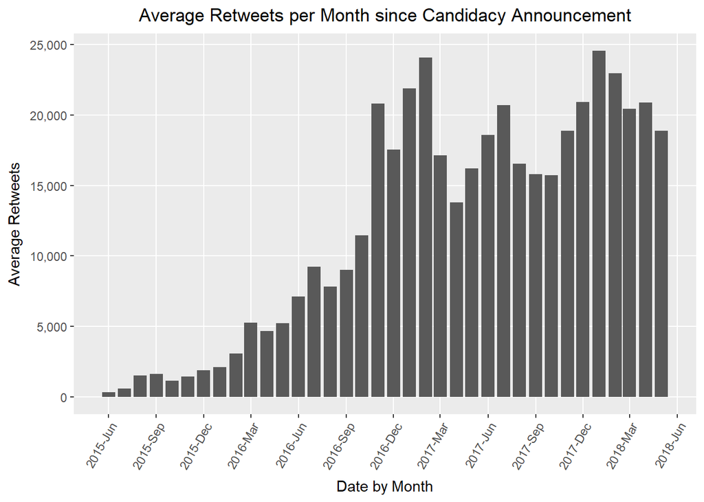

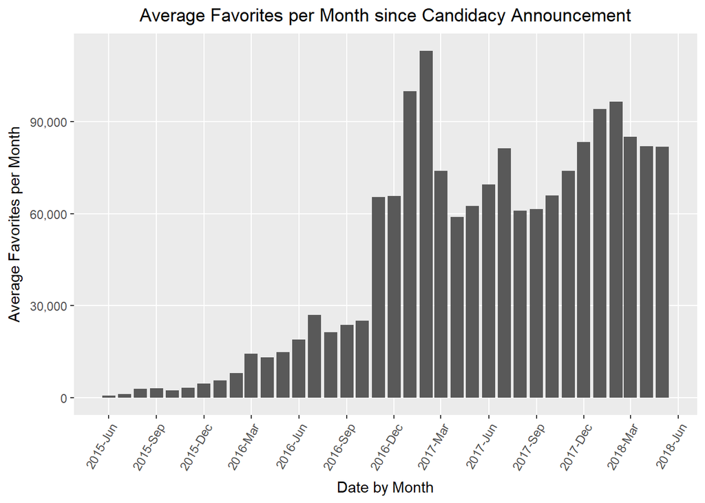

So when does he tweet? What’s his strategy?

First, a quick look at his Twitter history

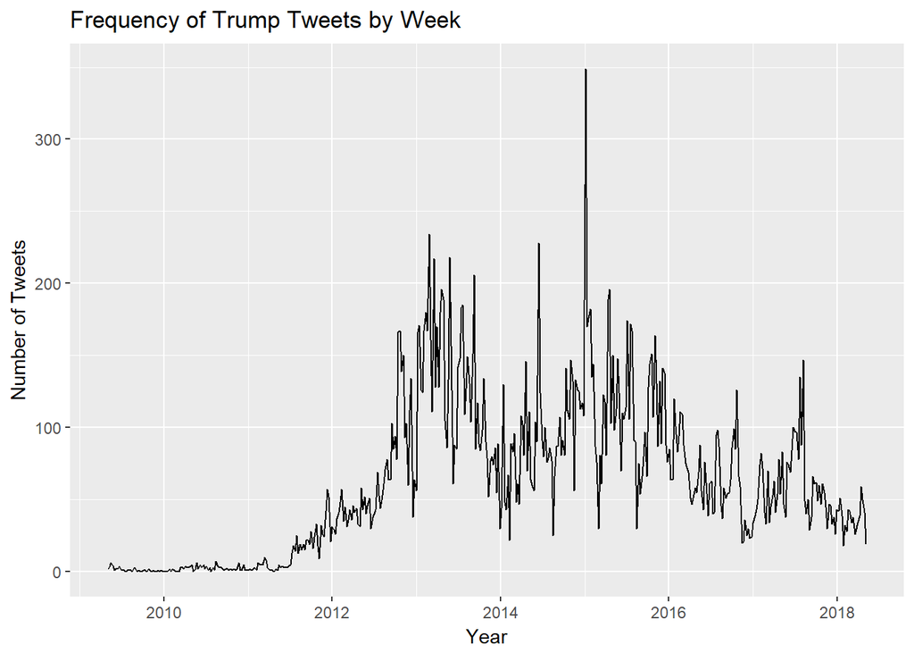

Here, we can see one of Trump’s well-documented habits: tweeting at 3 a.m. He heavily favors the evening, more frequently sending out tweets from 6-8 p.m.

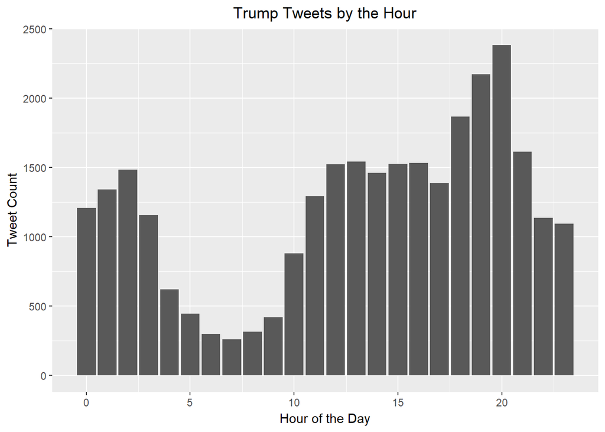

He also tends to follow the businessweek, with a large drop in tweets on the weekend.

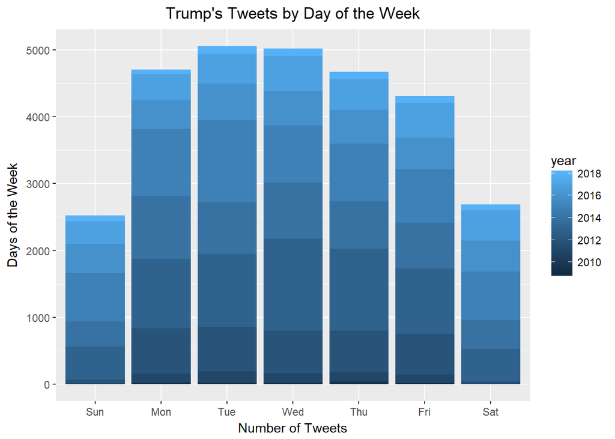

#### Trump Topics

Let’s look into Trump’s interactions and language style, as both can serve as indicators for topics he cares about.

Trump uses both hashtags and @ tags, but seems to favor @ tags. He uses them in tandem in 10.7 percent, only the hashtag in 6.5 percent and only the @ tag in 58.6 percent of his tweets.

Unsurprisingly, many of the top tags are related to his campaign, including Trump16, MakeAmericaGreatAgain, and AmericaFirst. CelebApprentice his reality show, is suprisingly high.

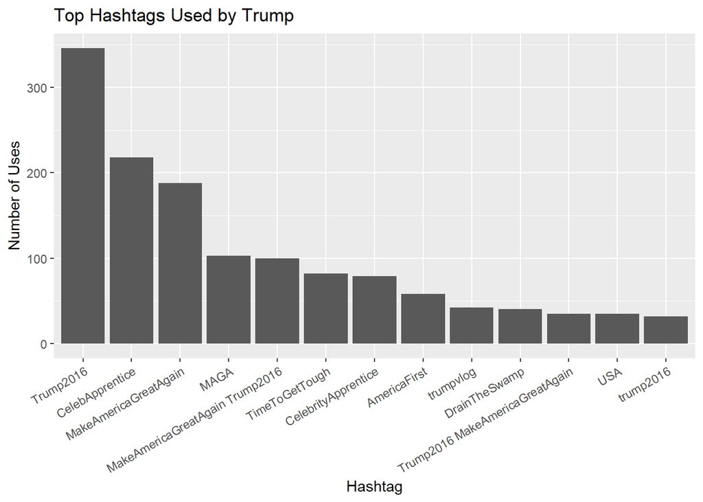

Trump’s @tags are also often politically minded, reference Barack Obama over 400 times and mentioning multiple news outlets, include foxandfriends, FoxNews, nytimes, and CNN.

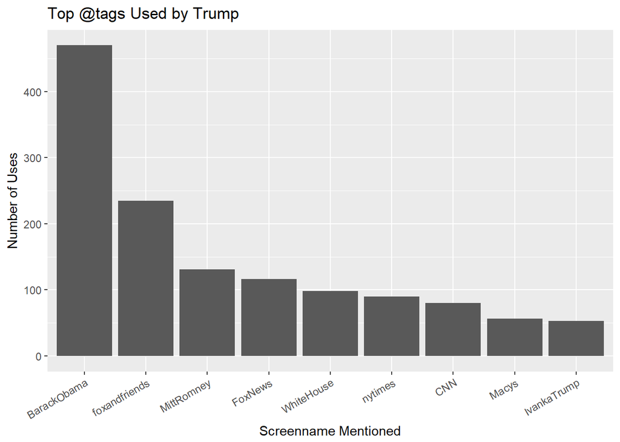

Note: although foxandfriends is in Trump’s top @ tags, the reverse is not true.

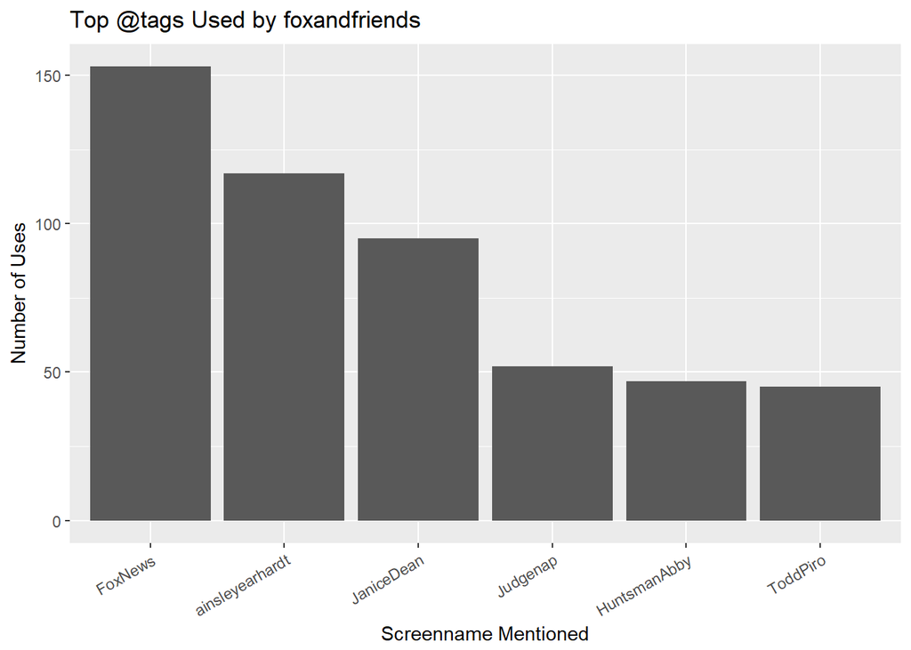

On the topic of news, how about fake news? The phrase appears in his tweets 184 times.

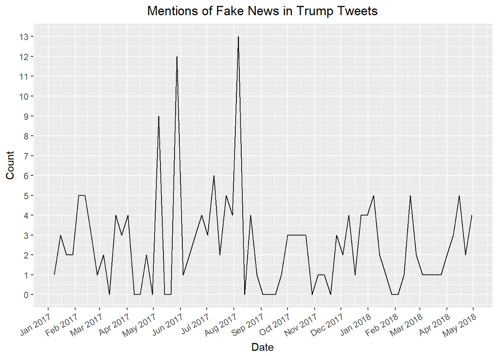

Trump’s choice of all caps also reflects his political cares and drives, including “Make America Great Again” and multiple news outlets.

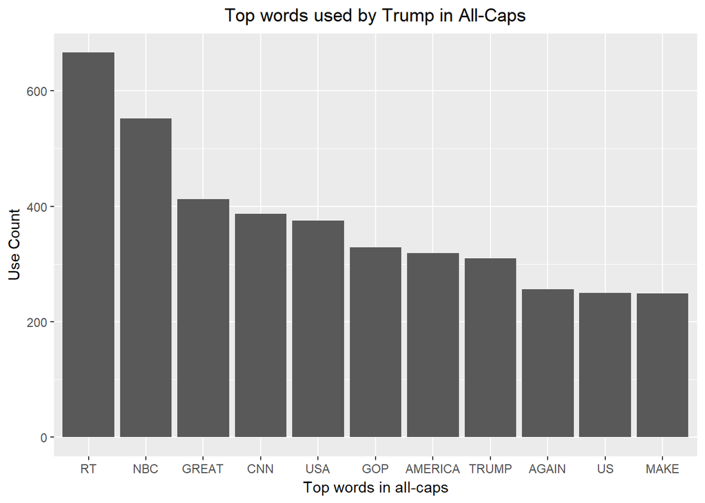

### @foxandfriends

An overview timeline of foxandfriends on Twitter:

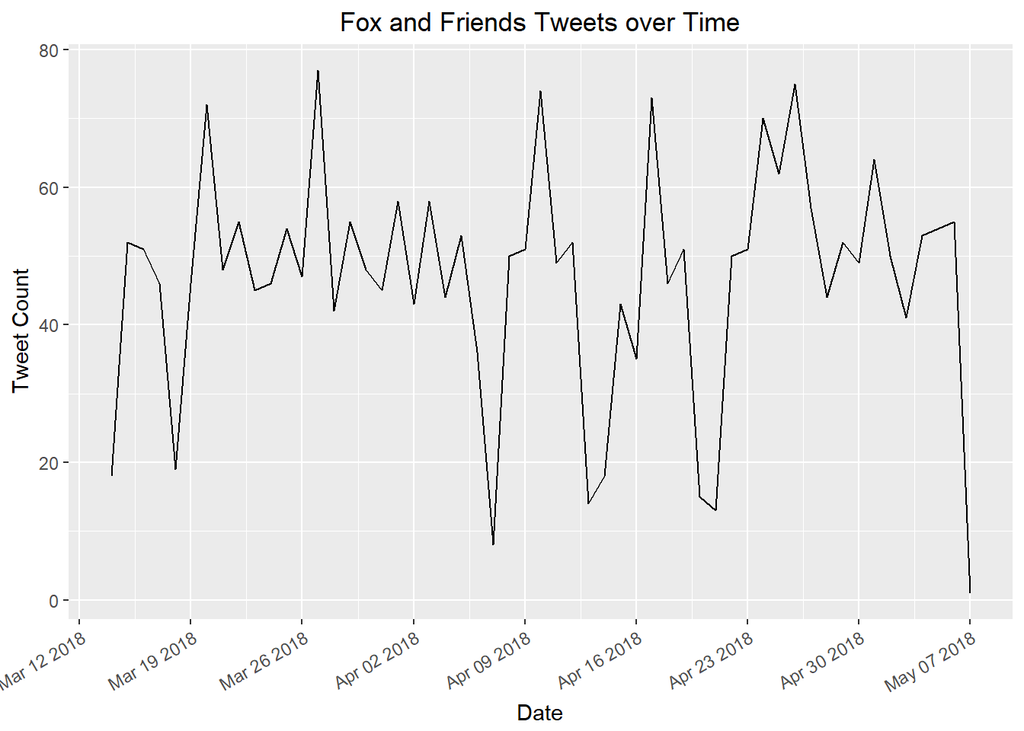

Foxandfriends follows much more traditional business hours, although there are some tweets in the evenings.

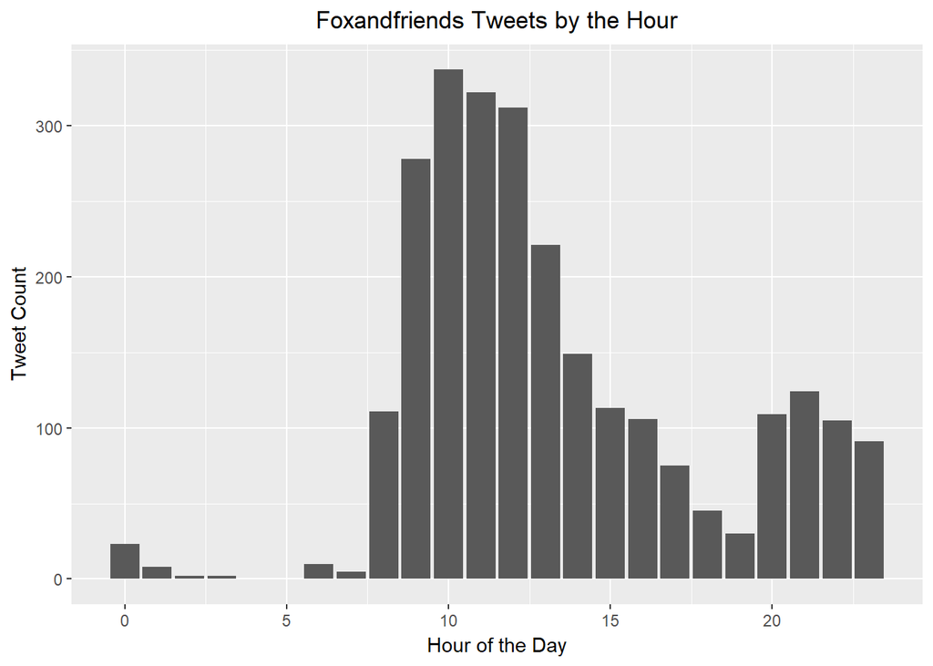

Foxandfriends appears to slightly favor Tuesdays, but does not tweet absurdly more or less on a particular day.

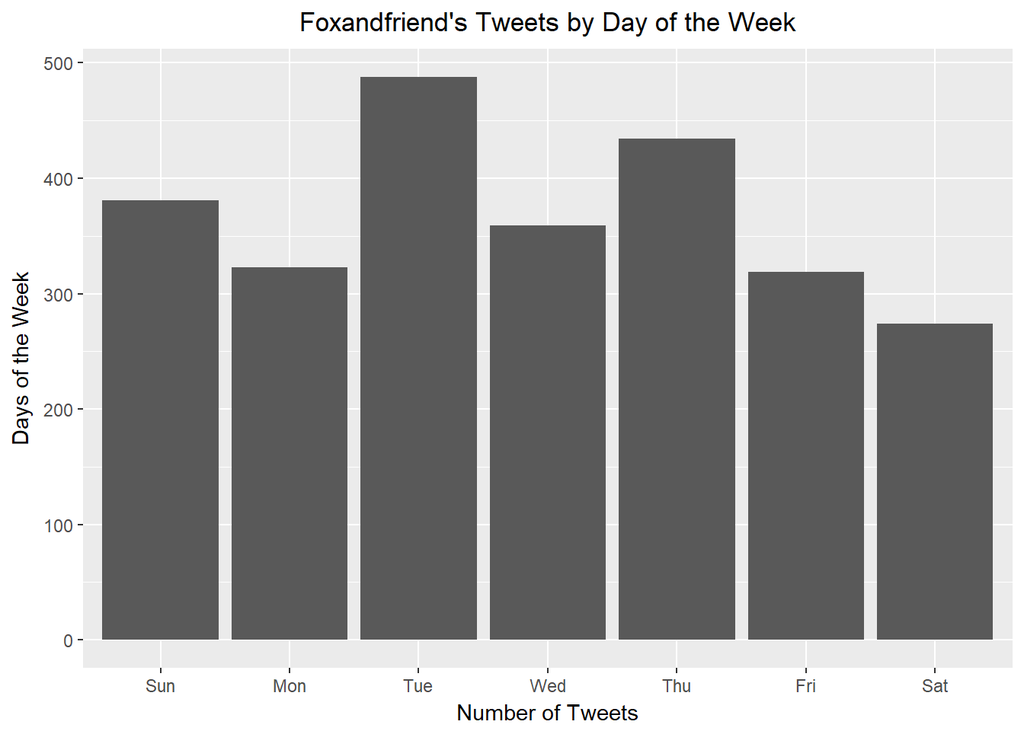